# Иллюстрации к статье

Вадим Хайтов

# Рисунок с датами ключевых событий

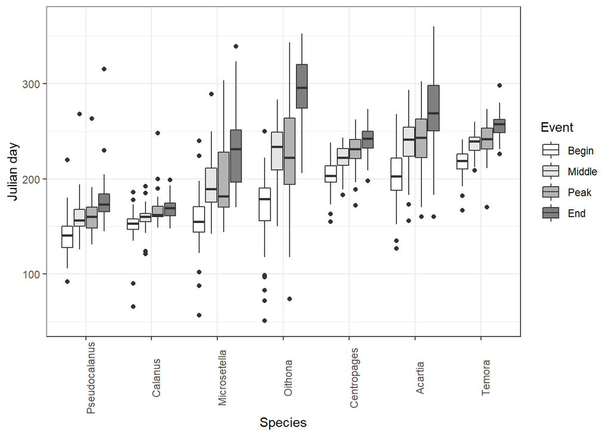

Подпись.

Боксплоты, отражающие распределения дат ключевых событий для изученных видов. Средняя линия - медиана, бокс ограничен значениями 1-st and 3-d quartiles, длина усов равна 1.5IQR (Wickham, Stryjewski, 2011), точки - “outlying” points.

# Риcунок с датами “климатических” событий

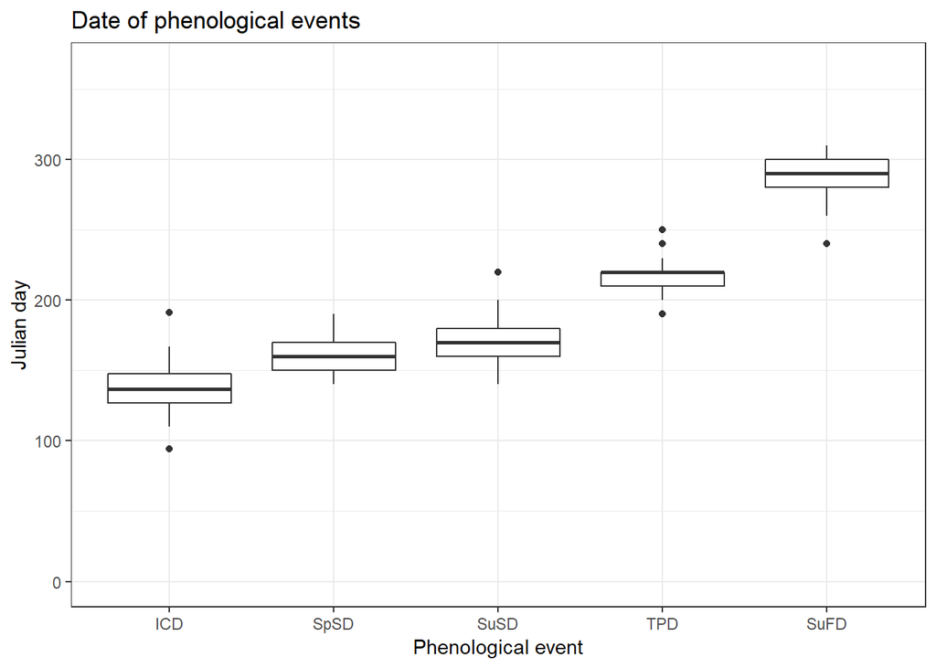

Подпись Боксплоты, отражающие распределение дат наиболее значимых гидрологических событий - ICD – Ice clear date  
- SpSD – Spring start date (the day when the water temperature overcomes 3 Celsium degrees)  
- SuSD – Summer start date (the day when the water temperature overcomes 5 Celsium degrees)  
- TPD – The date when the highest water temperaure was observed. - SuFD – The date of summer finnish

# Многолетние изменения фенологических показателей и обилия видов.

**Внимание!** Обилия, которые приводятся на этом рисунке - это срдение за Май - Октябрь по глубине 0-65м.

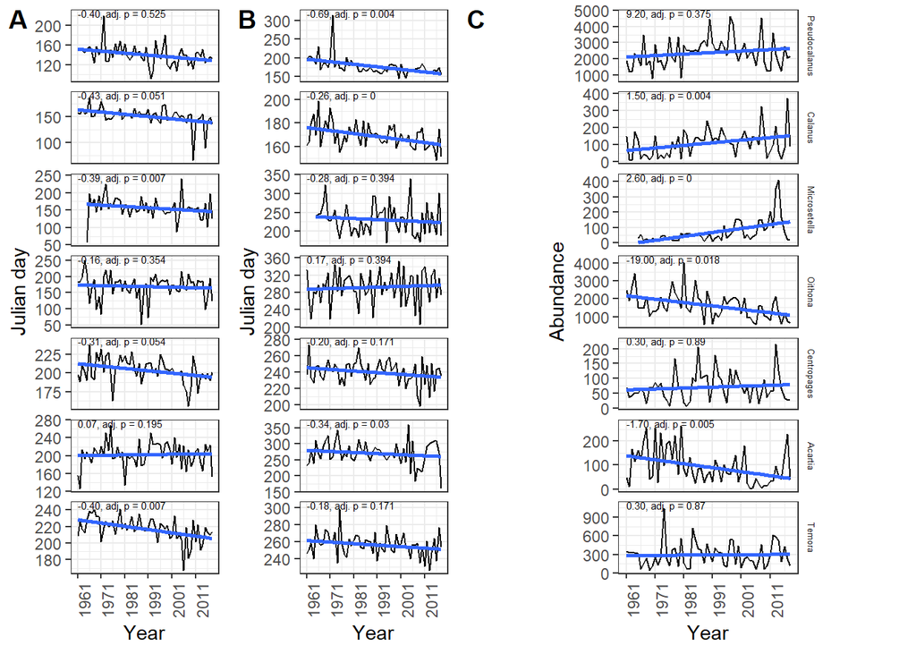

Подпись

Многолетние изменения даты начала сезона (A), даты конца сезона (B) и обилия видов копепод ($ind./m^3$) [**не уверен в том что на кубометр**]. Прямая линия - отражает линейную модель, связывающую значение, отложенное по оси ординат со временем. Числа над линией регрессии: угловой коэффициент данной модели и уровень значимости для мантеловской корреляции (детали в Материале и методах).

# Факторы, определяющие сдвиги в фенологии сообщества копепод

## Динамика показателей, включенных в анализ

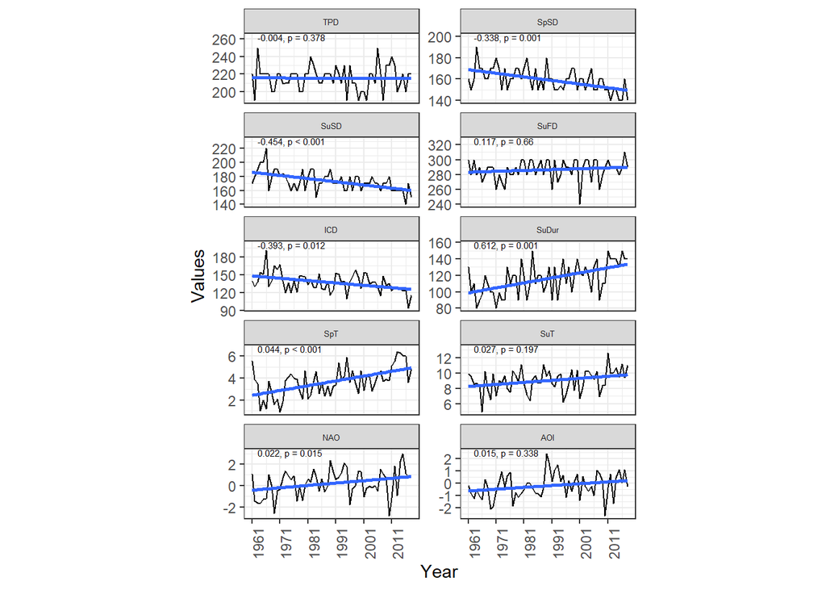

Подпись Многолетние изменения гидрологических и климатических факторов, включенных в анализ. Прямая линия - отражает линейную модель, связывающую значение, отложенное по оси ординат со временем. Числа над линией регрессии: угловой коэффициент данной модели и уровень значимости для мантеловской корреляции (детали в Материале и методах).

Обозначения

- TPD – Julian day when temperature maximum was observed
- SpSD – Julian day when hydrological spring started (water temperature reached 3 Celsium degree)
- SuSD – Julian day when hydrological summer started (water temperature reached 5 Celsium degree)
- SuFD – Julian day when hydrological summer finnished
- ICD – Julian day when ice clearing was observed
- SpT – Mean spring temperature
- SuT – Mean summer temperature
- SuDur – Summer duration (number of days)
- NAO – North Atlantic oscillation index
- AOI – Arctic oscillation index.

## Результаты ССА

### Результаты

Всего было рассмотрено 16 гидролого-климатических предикторов, 7 величин, описывающих биотические параметры (логарифмы обилия видов в данном году), а также год, как непрерывный предиктор, характеризующий линейный тренд в многолетних изменениях. Однако часть предикторов продемонстрировало высокую степень коллинеарности (взаимозависимости) поэтому их количество было сокращено (были удалены предикторы демонстрирующие VIF > 5). Оставшиеся предикторы были включены в модель канонического корреспондентного анализа.

**Коля и Даша! обратите внимание, что в этой верси я подумал и решил, что не будем редуцировать модель. Пусть будет все, что не коллинеарно. Мы отбракуем лишнее за счет значимости присутствия предиктора в мдели**

**ВАЖНО!** Теперь в ССА обилия учитываются в слое **0-25** метров за Май - Октябрь.

Table +1. Permutation significance test of the final CCA model

| term | df | ChiSquare | statistic | p.value |
| --- | --- | --- | --- | --- |
| Model | 18 | 0.0051739 | 1.344515 | 0.0188 |
| Residual | 35 | 0.0074825 | NA | NA |

Table +2. Permutation significance test of CCA constrained axis

| term | df | ChiSquare | statistic | p.value |
| --- | --- | --- | --- | --- |
| CCA1 | 1 | 0.0018428 | 8.6198877 | 0.0291 |
| CCA2 | 1 | 0.0010025 | 4.6891304 | 0.6874 |
| CCA3 | 1 | 0.0006272 | 2.9335919 | 0.9854 |
| CCA4 | 1 | 0.0004116 | 1.9252314 | 1.0000 |
| CCA5 | 1 | 0.0003583 | 1.6761881 | 1.0000 |
| CCA6 | 1 | 0.0002881 | 1.3475158 | 1.0000 |
| CCA7 | 1 | 0.0001773 | 0.8295549 | 1.0000 |
| CCA8 | 1 | 0.0001492 | 0.6978258 | 1.0000 |
| CCA9 | 1 | 0.0001063 | 0.4973057 | 1.0000 |
| CCA10 | 1 | 0.0000850 | 0.3975945 | 1.0000 |
| CCA11 | 1 | 0.0000547 | 0.2557591 | 1.0000 |
| CCA12 | 1 | 0.0000337 | 0.1576229 | 1.0000 |
| CCA13 | 1 | 0.0000158 | 0.0740193 | 1.0000 |
| CCA14 | 1 | 0.0000096 | 0.0450672 | 1.0000 |
| CCA15 | 1 | 0.0000067 | 0.0313990 | 1.0000 |
| CCA16 | 1 | 0.0000020 | 0.0093736 | 1.0000 |
| CCA17 | 1 | 0.0000016 | 0.0073436 | 1.0000 |
| CCA18 | 1 | 0.0000015 | 0.0068623 | 1.0000 |
| Residual | 35 | 0.0074825 | NA | NA |

Table +3. Permutation significance test of each terms included in the CCA model

| term | df | ChiSquare | statistic | p.value |
| --- | --- | --- | --- | --- |
| TPD | 1 | 0.0001802 | 0.8427885 | 0.5521 |
| SpSD | 1 | 0.0003523 | 1.6479590 | 0.1129 |
| SuSD | 1 | 0.0002833 | 1.3252996 | 0.2239 |
| SuFD | 1 | 0.0002302 | 1.0767415 | 0.3609 |
| ICD | 1 | 0.0002049 | 0.9583221 | 0.4522 |
| SuSDPY | 1 | 0.0001272 | 0.5949655 | 0.7807 |
| SuFDPY | 1 | 0.0005683 | 2.6584227 | 0.0139 |
| SuT | 1 | 0.0000779 | 0.3644613 | 0.9516 |
| SuTPY | 1 | 0.0001354 | 0.6331787 | 0.7559 |
| NAO | 1 | 0.0001370 | 0.6407839 | 0.7336 |
| AOIPY | 1 | 0.0001863 | 0.8714171 | 0.5239 |
| Acartia_N | 1 | 0.0004497 | 2.1036286 | 0.0453 |
| Calanus_N | 1 | 0.0003025 | 1.4149759 | 0.1875 |
| Centropages_N | 1 | 0.0000982 | 0.4592242 | 0.9035 |
| Microsetella_N | 1 | 0.0005256 | 2.4583831 | 0.0180 |
| Oithona_N | 1 | 0.0002505 | 1.1717901 | 0.3036 |
| Pseudocalanus_N | 1 | 0.0000785 | 0.3670388 | 0.9529 |
| Temora_N | 1 | 0.0001718 | 0.8035500 | 0.5887 |
| Residual | 35 | 0.0074825 | NA | NA |

Полученная модель, была статистически значима (Таблица +1) и (при учете всех канонических корреспондентных осей) объясняла 40.9% of total inertia. При этом из всех возможных канонических осей статистически значимой оказалась только первая каноническая ось (Таблица +2). На эту ось приходилось 14.6 of total inertia.

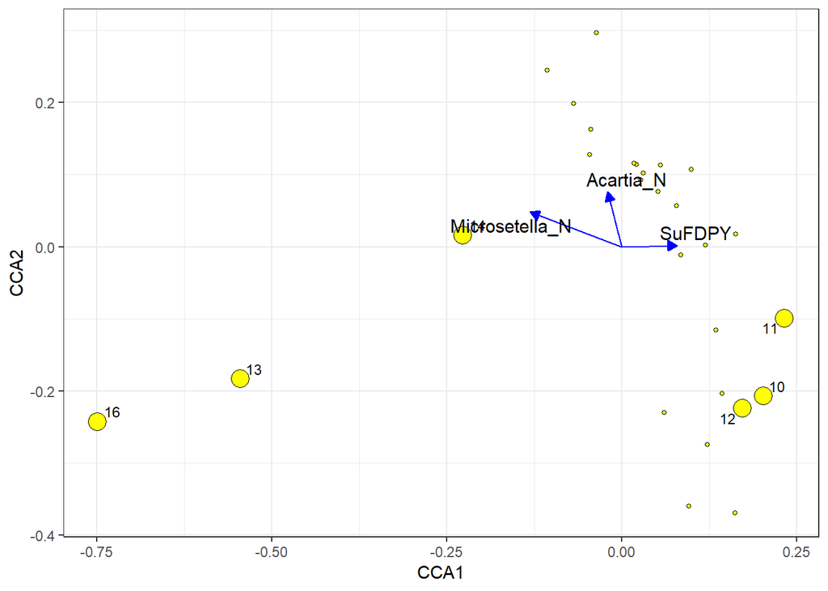

Подпись

Ординация фенологических параметров видов в ограниченных осях канонического корреспондентного анализа [Ordination of phenological characteristics of species in constrained axis of CCA]. Крупные пронумерованные точки соответствуют фенологическим показателям, которые имеют высокие значения первой канонической оси (без учета знака), то есть их значения находятся за пределами второго квартиля значений соответствующей оси. Стрелки обозначают предикторы, вошедшие в финальную модель.

Обозначения фенологических характеристик приведены в следующей таблице.

| Phenological Event | Label | Phenological Event | Label |
| --- | --- | --- | --- |
| Microsetella_Middle | 10 | NA | NA |
| Microsetella_End | 11 | NA | NA |
| Microsetella_Peak | 12 | NA | NA |
| Oithona_Begin | 13 | NA | NA |
| Oithona_Middle | 14 | NA | NA |
| Oithona_Peak | 16 | NA | NA |
| NA | NA | NA | NA |
| NA | NA | NA | NA |
| NA | NA | NA | NA |
| NA | NA | NA | NA |
| NA | NA | NA | NA |
| NA | NA | NA | NA |
| NA | NA | NA | NA |
| NA | NA | NA | NA |

# Связь обилия вида и его фенологических показателей

**Здесь понадобится кусок в материале и методах. Пока пишу длинно, но можно и сократить.**

При анализе корреляции между временными рядами, отражающими динамику обилия популяций, с одной стороны, и динамику внешних, не зависящих от плотности, факторов, с другой стороны, могут появляться высокие корреляции даже при отсутствии значимых связей между временными рядами (Royama, 1981).

*Royama, T. (1981). Fundamental concepts and methodology for the analysis of animal population dynamics, with particular reference to univoltine species. Ecological Monographs, 51(4), 473-493.*

В связи с этим, для выявления корреляции между обилием видов и их фенологическими характеристиками (в качестве фенологического маркера была выбрана дата начала сезона пребывания вида в планктоне) был использован dichotomous nominal scale correlations method (Royama, 1981; 1992).

*Royama, T. (1992) Analytical Population Dynamics. Chapman & Hall, London.*

Вкратце суть метода сводится к следующему.

Второй этап - анализ знака второй производной в каждой временной точке у двух временных рядов. Оба временных ряда были разбиты на скользящие локальные сегменты, состоящие из трех точек наблюдения $X_{t-1}, X_{t}$ - $X_{t}, X_{t+1}$ для временного ряда обилий и $u_{t-1}, u_{t}$ - $u_{t}, u_{t+1}$ для дат начала сезона. Если оба отрезка в точках $X_t$ и $u_t$ были вогнуты или оба были выпуклы (знак второй производной положительный или отрицательный, соответственно), то это считалось совпадением тенденций в двух временных рядах. Если знаки вторых производных были разные, то это считалось несовпадением. Далее было подсчитано количество совпадений ($p$) и количество несовпадений ($q$) при смещении сегментов вдоль временных рядов. После этого вычислялся коэффициент корреляции по следующей формуле:
$$\delta = \frac{p-q}{p+q}$$

Третий этап - оценка статистической значимости полученного значения. Для оценки статистической значимости полученных коэффициентов корреляции использовался пермутационный подход (Quinn, Keough, 2002). Производились случайные перестановки значений в ряду $\{X\}$ и в ряду $\{u\}$). После каждого акта пермутации вычислялся коэффициент корреляции. Всего было проведено 9999 пермутаций. Фактически наблюдаемый коэффициент корреляции был также включен в множество коэффициентов, полученных в случайном процессе. Уровень значимости вычислялся как отношение количества коэффициентов корреляции, полученных при случайных пермутациях, больших или равных коэффициенту, полученному при сравнении фактически наблюдаемых данных, к общему количеству пермутаций плюс 1. Далее, поскольку происходило множественное тестирования гипотез (анализ связи проводился у семи видов), то производилась корректировка уровня значимости в соответствии с процедурой контроля False Discovery Rate (Benjamini, Hochberg,1995).

*Quinn, G. P., & Keough, M. J. (2002). Experimental design and data analysis for biologists. Cambridge University Press.*

## Результаты

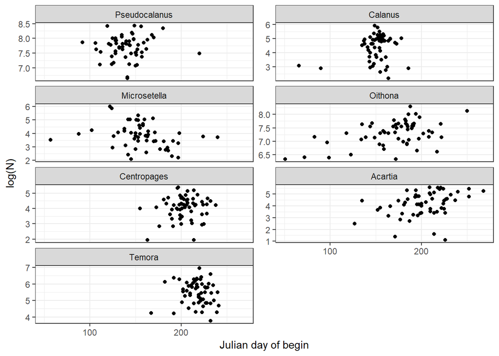

Подпись  
Связь между обилием вида в данном году и сроками начала сезона. Каждая точка соответствует отдельному году наблюдений.

Table +4. Correlation between time series reflectinging abundance and date of season begin

| Species | Correlation | Ajusted p-value |
| --- | --- | --- |
| Pseudocalanus | 0.04 | 1.0000 |
| Calanus | -0.11 | 1.0000 |
| Oithona | 0.04 | 1.0000 |
| Centropages | 0.00 | 1.0000 |
| Acartia | 0.04 | 1.0000 |
| Temora | -0.50 | 0.5298 |
| Microsetella | -0.42 | 0.2159 |